# Econ 204: HW 3

Karina Abou-Chakra, Jenna Anderson, Sydney Mayes

2023-05-15

```r
knitr::opts_chunk$set(echo = TRUE, warning = FALSE, message = FALSE, results = FALSE)
library(tidyverse)
library(here)
library(janitor)
library(equatiomatic)
```

```r
# Cleaning and tidying data
ca_ev <- read_csv(here('HW3_data.csv')) %>%
  clean_names()
long_ca_ev <- pivot_longer(ca_ev, cols = q_dac:q_non_dac, names_to = 'location', values_to = 'quantity')
```

## Question 1

*Run linear regressions (with an intercept) to estimate the demand curves for DAC and non-DAC consumers. What are 2-3 reasons you can think that may explain the differences in demand you estimate?*

**Demand curve for DAC:** p = -6.611437*q + 116854.835741

**Demand curve for non-DAC:** p = -2.730926*q + 158034.280239

**Visualizing the data shows that non-DAC groups demand more EVs than DAC groups. This may be because non-DAC groups have higher incomes and other monetary resources than DAC groups. It could also be because the local infrastructure is better developed for EV charging stations, thereby increasing demand further.**

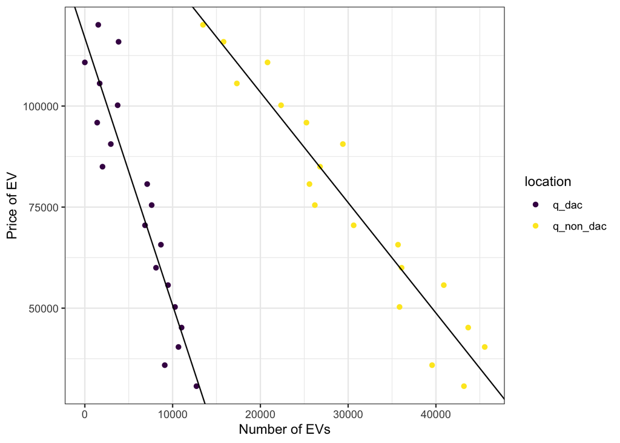

```r
# Run linear regressions
dac_model <- lm(price_dollars ~ quantity, data = filter(long_ca_ev, location == 'q_dac'))
dac_model$coefficients

non_dac_model <- lm(price_dollars ~ quantity, data = filter(long_ca_ev, location == 'q_non_dac'))
non_dac_model$coefficients

# Plot the data
ggplot(data = long_ca_ev, aes(x = quantity, y = price_dollars, col = location)) +
  geom_point() +
  geom_abline(slope = -6.611437, intercept = 116854.835741) +
  geom_abline(slope = -2.730926, intercept = 158034.280239) +
  #geom_abline(slope = -4.652827, intercept = 351488.7) +
  scale_color_viridis_d() +
  labs(x = 'Number of EVs', y = 'Price of EV' ) +
  theme_bw()
```

## Question 2

*One kilogram (kg) of lithium is estimated to cause $300 dollars worth of damage in health costs to local communities living near mines. Each EV requires a lithium ion battery containing 63kg of lithium. Assuming there are no other externalities caused by EV production, what is the marginal externality cost per EV produced?*

**18,900 dollars per EV**

```r
# Marginal externaliity cost is 63 kg * 300 dollars = 18,900 dollars per EV
63*300
```

## Question 3

*What is the aggregate annual demand curve for EVs?*

**If Price > 116854.835741: q = (158034.280239 - p)/2.730926** *or in terms of p:* **p = -2.730926(q) + 158034.280239**

**If Price <= 116854.835741: q = 75543.04 - 0.5174292(p)** *or in terms of p:* **p = 145996.9 - q/0.5174292**

What is the supply curve for EVs? **p = 1.006612(q)**

What is the “benefit” to consumers under the status quo? **Aggregate benefit to consumers (dac + nondac) is 2,474,913,243**

What is the “benefit” to producers under the status quo? **Aggregate benefit to producers (dac + nondac) is 1,241,789,394 dollars**

What is the environmental cost under the status quo? **938,792,782 dollars**

```r
# Dac demand function
# p = -6.611437q + 116854.835741 (dac)
# Putting in in terms of q
# 6.611437q = 116854.835741 - p
# q = (116854.835741 - p)/6.611437

dac_demand <- function(q) {
  p = -6.611437*q + 116854.835741
  return(p)
}

dac_demand_q <- function(p) {
  q = (116854.835741 - p)/6.611437
  return(q)
}

# Non-dac demand function
# p = -2.730926q + 158034.280239
# Putting it in terms of q
# 2.730926q = 158034.280239 - p
# q = (158034.280239-p)/2.730926


non_dac_demand <- function(q){
  p = -2.730926*q + 158034.280239
  return(p)
}

non_dac_demand_q <- function(p) {
  q = (158034.280239-p)/2.730926
  return(q)
}

# Add dac demand function + non-dac demand function to create aggregate function
# q = (116854.835741 - p)/6.611437 (dac) +
# q = (158034.280239-p)/2.730926 (non_dac) =
# q = 75543.04 - 0.5174292*p (agg)

# Putting it in terms of q
# 0.5174292*p = 75543.04 - q
# p = 75543.04/0.5174292 - q/0.5174292
# p = 145996.9 - 1.932632*q (agg)
# Aggregate annual demand curve is p = 145996.9 - 1.932632*q

agg_demand <- function(p) {
  if (p > 158034.280239) {
    non_dac_demand_q(p)
  }
  else {
    dac_demand_q(p) + non_dac_demand_q(p)
  }
}

# agg_demand(p = 0)

# Supply curve
agg_demand(50000) # 49671.58
supply_slope <- 50000/agg_demand(50000)
supply_slope # 1.006612

# Slope of supply curve = 50000/49671.59 = 1.006612
# Supply curve for EVs is P = 1.006612*Q
# 1.006612*q = 145996.9 - 1.932632*q (when supply curve = d_agg)
# 2.939244*q = 145996.9
# q = 49671.58

# Benefit to consumers under status quo is (39559.58)*(158034.280239-50000)*(1/2) for non-DAC
non_dac_demand_q(50000)*(158034.280239-50000)*(1/2) # 2136895270

# Benefit to consumers under status quo is (10112)*(116854.835741-50000)*(1/2) for DAC
dac_demand_q(50000)*(116854.835741-50000)*(1/2) # 338017973


# Aggregate benefit is 2136895270 + 338017973 = 2474913243


# Benefit to producers surplus under status quo:
(1/2)*(50000)*(agg_demand(50000)) # 1241789394

# Environmental cost
env_cost <- 18900 * agg_demand(50000)  # 938792782
```

## Question 4

How is the current consumer benefit divided between DAC and non-DAC consumers?

**Dac consumers get 13.66 percent of consumer benefit** **Non-dac consumers get 86.32 percent of consumer benefit**

```r
# Benefit to consumers under status quo:
# 86.32 percent for non-dac
# 13.66 percent for dac
2136895270/(2136895270+338017973) #  0.8634223
338017973/(2136895270+338017973) # 0.1365777
```

## Question 5

*Derive the optimal EV tax (in $ per vehicle) to internalize the lithium mining externality. Noting that recent research has shown that DACs are far more likely to contain mining activity, assume that the mining externality is borne entirely by the DAC group. What would be the effects of this tax on:*

**The optimal EV tax is 18,900 per vehicle. The effects of this tax are:**

1. The amount of EVs produced and consumed **The number of EVs produced would decrease from 49671.58 to 39892.17, resulting in a difference of about** 9,779 vehicles**
2. The price of EVs **The price of EVs would would increase by 18,900 each from 50,000 to 68,900 dollars.**
3. Overall welfare of non-DAC consumers **The consumer benefit for non-DAC consumers is now 1,454,620,139. This is down from 2,136,895,270 resulting in a decrease of 682,275,131 dollars.**
4. Overall welfare of DAC consumers **The consumer benefit for DAC consumers is now 173,915,767. Since the mining externality applies only to DAC consumers, we therefore subtract the total environmental damage of 753,961,894 from this number and get a negative welfare value of 580,046,127 dollars.**
5. EV producers **The benefit to producers is now 1,374,285,039**
6. Total environmental damage **753,961,894 dollars**
7. Total tax revenue generated **753,961,894**

```r
# New supply curve
# p = 1.006612*Q + 18,900

# supply original
supply_original <- function(q) {
  p = 1.006612*q
  return(p)
}

# new supply
supply_new <- function(q) {
  p = 1.006612*q + 18900
  return(p)
}

#q_agg at 50,000 = 75543.04 - 0.5174292*50000 = 49671.58
#q_agg at 50000 + 18900 = 75543.04 - 0.5174292*68900 = 39892.17
# 49671.58- 39892.17 = 9779.41

agg_demand(50000) - agg_demand(68900) #  9779.412

# c) Overall welfare of non-DAC consumers:
non_dac_demand_q(68900)*(158034.280239-68900)*(1/2) # 1454620139
2136895270 - 1454620139 # 682275131

# d) Overall welfare of DAC consumers:
dac_demand_q(68900)*(116854.835741-68900)*(1/2) # 173915767
338017973-173915767 # 164102206
# Now assume the mining externality applies only to dac
env_cost_plus_tax <- agg_demand(68900)*18900 # 753961894

# -753961894 + 173915767 = -580046127

# e) Benefit to producers
(1/2)*(68900)*(agg_demand(68900)) # 1374285039
 1241789394 - 1374285039 #  -132495645

# f) Total environmental damage
 env_cost_plus_tax

# g) Total tax revenue generated should be the same as the total damage.
```

## Question 6

*Now, assume that all revenue from the EV tax will be redistributed to the consumers in proportion to their pre-tax consumption. For example, if 80% of the EVs were consumed by non-DAC consumers, then they get 80% of the tax revenue. Additionally, consider that emerging scientific evidence suggests the true environmental damages from lithium mining may be much higher than $300. For a range of values of external costs per kg of lithium ($350, $400, $450, and $500 per kg), calculate the effects of an EV tax on:*

For this question we will go through the same procedure as question 5 but use different values that reflect other scenarios where the external costs of lithium are larger. Below shows how the EV tax changes when the external cost of lithium increases.

when external cost of lithium = $300, then the EV tax is 18,900 dollars

when external cost of lithium = $350, then the EV tax is 22,050 dollars

when external cost of lithium = $400, then the EV tax is 25,200 dollars

when external cost of lithium = $450, then the EV tax is 28,350 dollars

when external cost of lithium = $500, then the EV tax is 31,500 dollars

**(a) Overall welfare of non-DAC consumers:**

for 350 external cost: **1,168,749,542 dollars**

for 400 external cost: **1,084,684,762 dollars**

for 450 external cost: **1,003,757,126 dollars**

for 500 external cost: **925,966,634 dollars**

**(b) Overall welfare of DAC consumers:**

for 350 external cost: **20,734,984 dollars**

for 400 external cost: **17,921,930 dollars**

for 450 external cost: **15,313,853 dollars**

for 500 external cost: **12,910,753 dollars**

**(c) EV producers**

for 350 external cost: **1,378,397,977 dollars**

for 400 external cost: **1,377,376,723 dollars**

for 450 external cost: **1,371,221,278 dollars**

for 500 external cost: **1,359,931,642 dollars**

```r
mec_calc <- function(damage) {
   mec = damage * 63
   return(mec)
}

mec_300 <- mec_calc(300) + 50000
mec_350 <- mec_calc(350) + 50000
mec_400 <- mec_calc(400) + 50000
mec_450 <- mec_calc(450) + 50000
mec_500 <- mec_calc(500) + 50000


# Non-dac calcs
non_dac_demand_q(mec_350)*(158034.280239-mec_350)*(1/2)*(0.8634223) #1168749542
non_dac_demand_q(mec_400)*(158034.280239-mec_400)*(1/2)*(0.8634223) #1084684762
non_dac_demand_q(mec_450)*(158034.280239-mec_450)*(1/2)*(0.8634223) #1003757126
non_dac_demand_q(mec_500)*(158034.280239-mec_500)*(1/2)*(0.8634223) #925966634

# Dac calcs
dac_demand_q(mec_350)*(116854.835741-mec_350)*(1/2)*(0.1365777) #20734984
dac_demand_q(mec_400)*(116854.835741-mec_400)*(1/2)*(0.1365777) #17921930
dac_demand_q(mec_450)*(116854.835741-mec_450)*(1/2)*(0.1365777) #15313853
dac_demand_q(mec_500)*(116854.835741-mec_500)*(1/2)*(0.1365777) #12910753

# Producer calcs
(1/2)*(mec_350)*(agg_demand(mec_350)) #1378397977
(1/2)*(mec_400)*(agg_demand(mec_400)) #1377376723
(1/2)*(mec_450)*(agg_demand(mec_450)) #1371221278
(1/2)*(mec_500)*(agg_demand(mec_500)) #1359931642
```

## Question 7

1. How does the presence of climate change damages from gasoline cars affect the optimal EV tax in California?

**The presence of climate change damages from gasoline cars decreases the optimal EV tax in California, due to the ofsetting of the impacts of climate change. As the optimal EV tax decreases, the demand for EVs will incease, which will lead to a reduction in negative climate change impacts.**

2. Assuming tax revenue does not get returned to consumers, are non-DAC consumers more or less likely to support this new tax, relative to the tax that only accounts for the mining externality? Why?

**Non-DAC consumers will favor the EV tax because it will lower the tax on EVs, which are in high demand by non-DAC consumers.**

3. Assuming tax revenue does not get returned to consumers, are DAC consumers more or less likely to support this new tax, relative to the tax that only accounts for the mining externality? Why?

**The DAC consumers are less likely to support this new tax since it will decrease the overall cost of the EV, thus increasing the quantity, and lead to increased lithium mining. DAC communities would be subjected to direct environmental impacts from increased lithium mining, yet they would not be receiving the tax revenue to make up for these damages.**